# Influences on the likelihood and latency to be helped

Author

Liza Moscovice, Anja Eggert and Jean-Loup Rault

Published

July 10, 2023

# Libraries

```r
library(tidyverse)     # tidy universe
library(fastDummies)   # create dummy coded factors
library(survival)      # create survival object and survival curves
library(survminer)     # model diagnostics
library(lmtest)        # lrtest() model comparison
```

```r
set.seed(1989)
```

# Data

Using survival analysis to analyse time to open door for trapped pigs. Data set contains time-resolved data from 58 trapped pigs who were trapped for at least one minute.

## Read data

```r
dat <- read_csv("../data/survival-distress.csv")
```

## Adjust data types

```r
dat <- dat %>%
  # make factors
  mutate_at(vars(distress.binom,
                 sex,
                 location.test.box,
                 uniq.group,
                 trapped.pig.uniq.id), ~as.factor(.)) %>%
  mutate(invest.window.sq.z        = as.vector(scale(sqrt(invest.window.num)))) %>%
  mutate(time.trial.begins.z       = as.vector(scale(time.trial.begins))) %>%
  mutate(group.trapped.pig.order.z = as.vector(scale(group.trapped.pig.order)))
```

# Define survival object

- create `tstart` and `tstop` columns to define a time-varying survival object

```r
dat <- dat %>%
  group_by(trapped.pig.uniq.id) %>%
  mutate(tstop  = interval_count) %>%
  mutate(tstart = interval_count-1) %>%
  ungroup()
```

- maximum duration of the tests was 20 minutes, *i.e.* if time to release trapped pigs `lat.helped.min` = 20 (or the aborted trial) we have *right censored data*
- create `event` column, `event = 1` if `lat.helped.min` < 20 (pigs were helped within the test period), all others have `event = 0`, i.e. those were not helped within the test period.

```r
dat <- dat %>%
  mutate(event = 0L) %>%
  group_by(trapped.pig.uniq.id) %>%
  # last obs for each pig = 1
  mutate(event = case_when(outcome2 == "Full_trial" &
                           lat.helped.min < 20 ~
                           replace(event,n(), 1L),
                           TRUE ~ 0L)) %>%
  ungroup() %>%
  arrange(trapped.pig.uniq.id)
```

- check correct definition of the survival object using `survival::Surv()`: a “+” at the end of a one-minute interval indicates that the pig is still trapped at the end of that interval. If the last interval for a pig has a plus, this means that the observation is right censored (i.e., the pig was not helped within 20 minutes or the trial was aborted before 20 minutes).

```r
with(dat, survival::Surv(tstart, tstop, event))
```

```
  [1] ( 0, 1+] ( 1, 2+] ( 2, 3+] ( 3, 4+] ( 4, 5+] ( 5, 6+] ( 6, 7+] ( 7, 8+]
  [9] ( 8, 9+] ( 9,10+] (10,11]  ( 0, 1+] ( 1, 2+] ( 2, 3+] ( 3, 4+] ( 4, 5+]
 [17] ( 5, 6+] ( 6, 7+] ( 7, 8+] ( 8, 9+] ( 9,10+] (10,11+] (11,12+] (12,13+]
 [25] (13,14+] (14,15+] (15,16+] (16,17+] (17,18+] (18,19+] ( 0, 1+] ( 1, 2+]
 [33] ( 2, 3]  ( 0, 1]  ( 0, 1+] ( 1, 2+] ( 2, 3+] ( 3, 4+] ( 4, 5+] ( 5, 6+]
 [41] ( 6, 7+] ( 7, 8+] ( 8, 9+] ( 9,10+] (10,11+] (11,12+] (12,13+] (13,14+]
 [49] (14,15+] (15,16+] (16,17+] (17,18+] (18,19+] ( 0, 1+] ( 1, 2+] ( 2, 3+]
 [57] ( 3, 4+] ( 4, 5+] ( 5, 6+] ( 6, 7+] ( 7, 8+] ( 8, 9+] ( 9,10+] (10,11+]
 [65] (11,12+] (12,13+] (13,14+] (14,15+] (15,16+] (16,17+] (17,18+] (18,19+]
 [73] ( 0, 1]  ( 0, 1+] ( 1, 2+] ( 2, 3]  ( 0, 1+] ( 1, 2+] ( 2, 3+] ( 3, 4]
 [81] ( 0, 1]  ( 0, 1+] ( 1, 2+] ( 2, 3+] ( 3, 4+] ( 4, 5+] ( 5, 6+] ( 6, 7+]
 [89] ( 7, 8+] ( 8, 9+] ( 9,10+] (10,11+] (11,12+] (12,13+] (13,14+] (14,15+]
 [97] (15,16+] (16,17+] (17,18+] (18,19+] ( 0, 1]  ( 0, 1+] ( 1, 2+] ( 2, 3+]
[105] ( 3, 4+] ( 4, 5+] ( 5, 6+] ( 6, 7+] ( 7, 8+] ( 8, 9+] ( 9,10+] (10,11+]
[113] (11,12+] (12,13]  ( 0, 1+] ( 1, 2+] ( 2, 3+] ( 0, 1]  ( 0, 1+] ( 1, 2+]
```

[output cut: 29 more lines]

# Cox proportional hazards model

- run a Cox proportional hazards model (*Cox PH model* or sometimes Cox PH regression) with time-dependent covariates

## Run full model

```r
mod <- survival::coxph(
  survival::Surv(tstart, tstop, event) ~
    # test predictors
    distress.binom            +
    invest.window.sq.z        +
    # control predictors
    sex                       +
    time.trial.begins.z       +
    location.test.box         +
    group.trapped.pig.order.z +
    uniq.group,
  data = dat,
  cluster = trapped.pig.uniq.id)
```

## Run reduced model

```r
mod.red <- survival::coxph(
  survival::Surv(tstart, tstop, event) ~
    # test predictors: none
    # control predictors
    sex                       +
    time.trial.begins.z       +
    location.test.box         +
    group.trapped.pig.order.z +
    uniq.group,
  data = dat,
  cluster = trapped.pig.uniq.id)
```

## Model comparison

```r
lmtest::lrtest(mod.red, mod)
```

```
Likelihood ratio test

Model 1: survival::Surv(tstart, tstop, event) ~ sex + time.trial.begins.z +
    location.test.box + group.trapped.pig.order.z + uniq.group
Model 2: survival::Surv(tstart, tstop, event) ~ distress.binom + invest.window.sq.z +
    sex + time.trial.begins.z + location.test.box + group.trapped.pig.order.z +
    uniq.group
  #Df  LogLik Df  Chisq Pr(>Chisq)
1  11 -158.88
2  13 -156.49  2 4.7993    0.09075 .
---
Signif. codes:  0 '***' 0.001 '**' 0.01 '*' 0.05 '.' 0.1 ' ' 1
```

## Testing Proportional Hazards Assumption

- testing proportional hazards (PH) assumption using graphical diagnostics based on the scaled Schoenfeld residuals

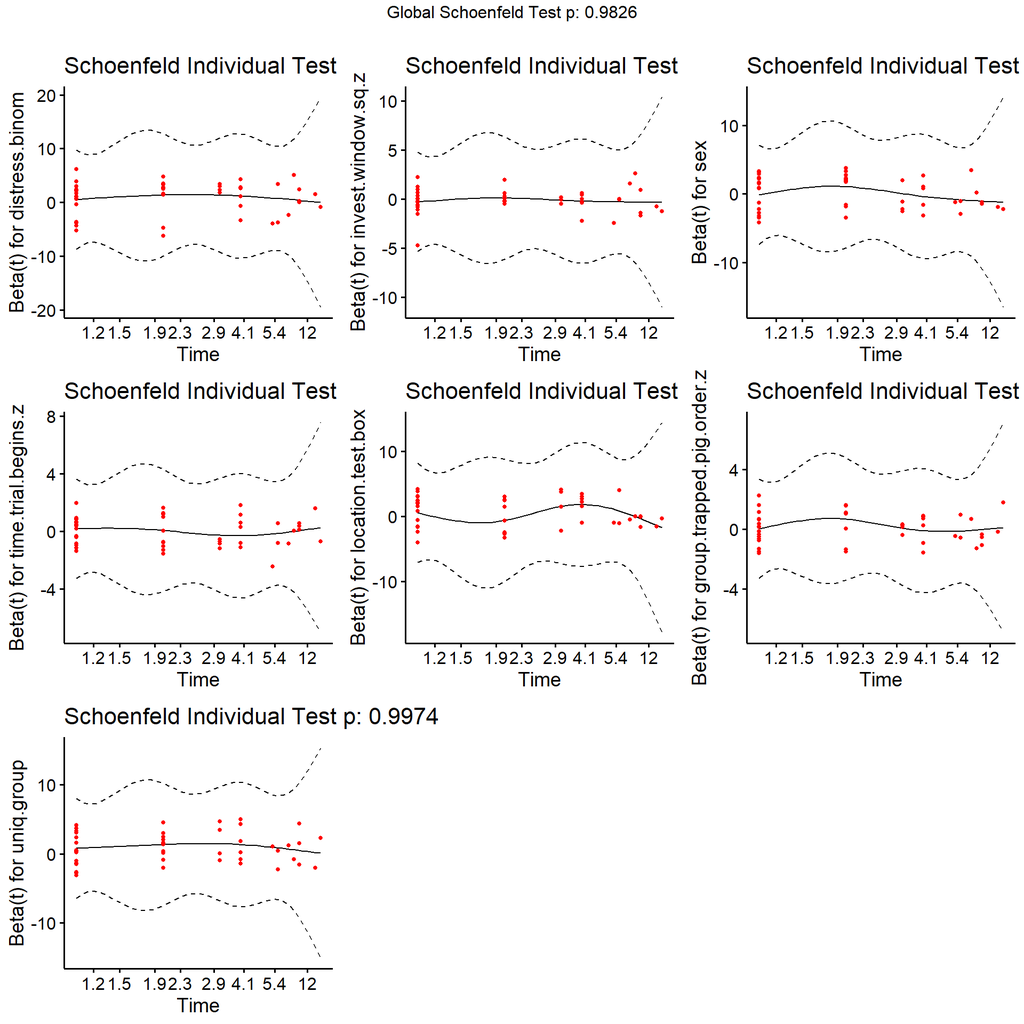

```r
survminer::ggcoxzph(cox.zph(mod))
```

## Testing Influential Observations

- testing for influential observations or outliers using graphical diagnostics of the deviance residuals

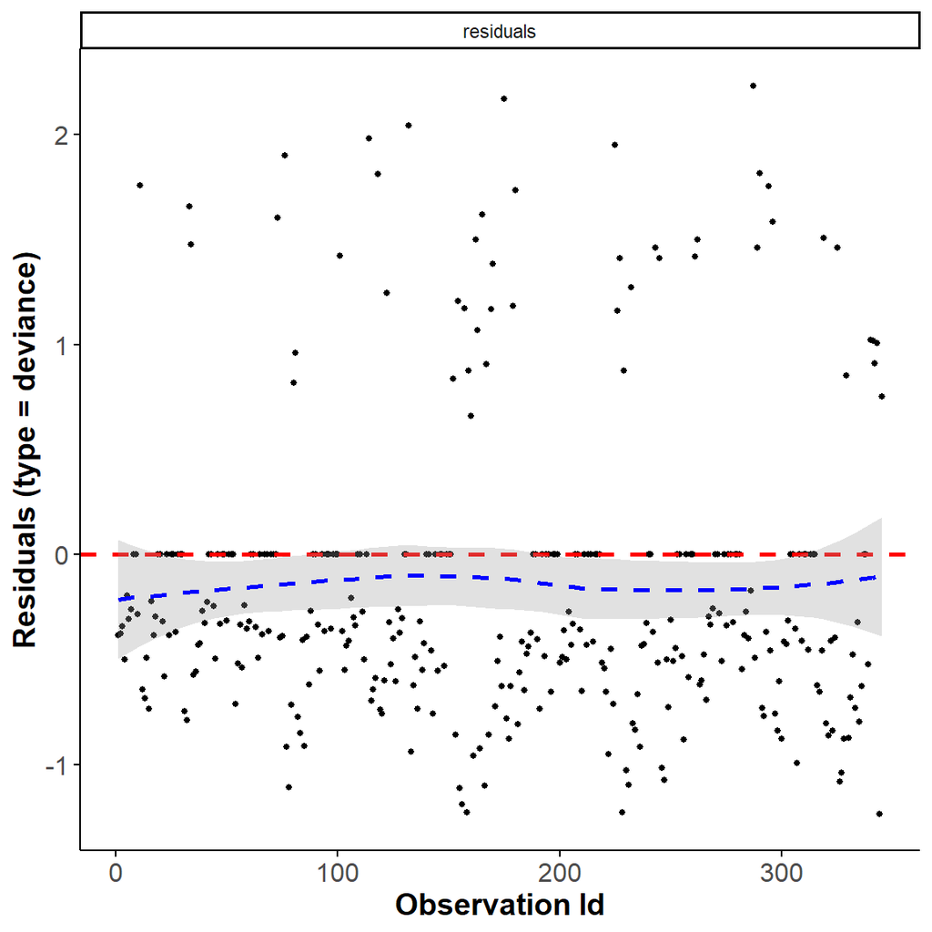

```r
survminer::ggcoxdiagnostics(mod, type = "deviance",
                 linear.predictions = FALSE, ggtheme = my_theme)
```

# Analysis of Deviance Table

- with `car::Anova()` we calculate deviance table and $Wald$ statistic, type II because of no interactions

```r
car::Anova(mod, type ="II", test.statistic = "Wald")
```

```
Analysis of Deviance Table (Type II tests)

Response: survival::Surv(tstart, tstop, event)
                          Df   Chisq Pr(>Chisq)
distress.binom             1  4.6505    0.03104 *
invest.window.sq.z         1  0.8094    0.36829
sex                        1  0.0276    0.86817
time.trial.begins.z        1  0.0427    0.83628
location.test.box          1  1.3696    0.24188
group.trapped.pig.order.z  1  0.9056    0.34129
uniq.group                 7 16.2565    0.02287 *
---
Signif. codes:  0 '***' 0.001 '**' 0.01 '*' 0.05 '.' 0.1 ' ' 1
```

# Hazard ratios

```r
summary(mod)
```

```
Call:
survival::coxph(formula = survival::Surv(tstart, tstop, event) ~
    distress.binom + invest.window.sq.z + sex + time.trial.begins.z +
        location.test.box + group.trapped.pig.order.z + uniq.group,
    data = dat, cluster = trapped.pig.uniq.id)

  n= 345, number of events= 48

                              coef exp(coef) se(coef) robust se      z Pr(>|z|)
distress.binom1            0.86149   2.36668  0.41076   0.39948  2.156   0.0310
invest.window.sq.z        -0.17903   0.83608  0.22499   0.19899 -0.900   0.3683
sexMale                   -0.05416   0.94728  0.34216   0.32628 -0.166   0.8682
time.trial.begins.z        0.02931   1.02975  0.15980   0.14186  0.207   0.8363
location.test.boxSide      0.39256   1.48077  0.34262   0.33544  1.170   0.2419
group.trapped.pig.order.z  0.15229   1.16450  0.16160   0.16003  0.952   0.3413
uniq.groupBatch1_B         1.46168   4.31320  0.91796   0.79582  1.837   0.0663
uniq.groupBatch2_A        -0.14421   0.86570  0.66736   0.72302 -0.199   0.8419
uniq.groupBatch2_B         1.00209   2.72398  0.62280   0.65190  1.537   0.1242
uniq.groupBatch3_A         0.50940   1.66429  0.64097   0.68782  0.741   0.4589
uniq.groupBatch3_B         0.72526   2.06527  0.60601   0.62339  1.163   0.2447
uniq.groupBatch4_A        -0.03556   0.96506  0.62055   0.66948 -0.053   0.9576
uniq.groupBatch4_B         1.32897   3.77716  0.64840   0.60352  2.202   0.0277

distress.binom1           *
invest.window.sq.z
sexMale
time.trial.begins.z
location.test.boxSide
group.trapped.pig.order.z
uniq.groupBatch1_B        .
uniq.groupBatch2_A
uniq.groupBatch2_B
uniq.groupBatch3_A
uniq.groupBatch3_B
uniq.groupBatch4_A
uniq.groupBatch4_B        *
---
Signif. codes:  0 '***' 0.001 '**' 0.01 '*' 0.05 '.' 0.1 ' ' 1

                          exp(coef) exp(-coef) lower .95 upper .95
distress.binom1              2.3667     0.4225    1.0817     5.178
invest.window.sq.z           0.8361     1.1961    0.5661     1.235
sexMale                      0.9473     1.0557    0.4997     1.796
time.trial.begins.z          1.0297     0.9711    0.7798     1.360
location.test.boxSide        1.4808     0.6753    0.7673     2.858
group.trapped.pig.order.z    1.1645     0.8587    0.8510     1.594
uniq.groupBatch1_B           4.3132     0.2318    0.9066    20.521
uniq.groupBatch2_A           0.8657     1.1551    0.2099     3.571
uniq.groupBatch2_B           2.7240     0.3671    0.7591     9.775
uniq.groupBatch3_A           1.6643     0.6009    0.4323     6.408
uniq.groupBatch3_B           2.0653     0.4842    0.6086     7.008
uniq.groupBatch4_A           0.9651     1.0362    0.2598     3.584
uniq.groupBatch4_B           3.7772     0.2647    1.1573    12.328

Concordance= 0.685  (se = 0.041 )
Likelihood ratio test= 15.82  on 13 df,   p=0.3
Wald test            = 28.8  on 13 df,   p=0.007
Score (logrank) test = 15.25  on 13 df,   p=0.3,   Robust = 20.99  p=0.07

  (Note: the likelihood ratio and score tests assume independence of
     observations within a cluster, the Wald and robust score tests do not).
```

# Survival curves

- fit an additional **plot.model** with all predictors except the predictor of interest (`distress.binom`) having a mean of zero

## Dummy-coding

- using `fastDummies` to dummy-code categorical predictors, continuous predictors are z-transformed

```r
dat.distress <- fastDummies::dummy_cols(dat,
                                   select_columns = c(
                                     "sex",
                                     "uniq.group",
                                     "location.test.box"),
                                   remove_first_dummy = TRUE) %>%
  mutate_at(vars(starts_with("sex_")),
            ~(.)-mean(.)) %>%
  mutate_at(vars(starts_with("uniq.group_")),
            ~(.)-mean(.)) %>%
  mutate_at(vars(starts_with("location.test.box_")),
            ~(.)-mean(.))
```

## Run plot model

- estimate two survival curves for `distress.binom`, *i.e.* distress yes/no

```r
plot.mod <- survival::coxph(
  survival::Surv(tstart, tstop, event) ~
    # strata distress
    strata(distress.binom) +
    # sex
    sex_Male +
    # uniq.group
    uniq.group_Batch1_B +
    uniq.group_Batch2_A + uniq.group_Batch2_B +
    uniq.group_Batch3_A + uniq.group_Batch3_B +
    uniq.group_Batch4_A + uniq.group_Batch4_B +
    # location.test.box
    location.test.box_Side    +
    # continuous predictors
    invest.window.sq.z        +
    time.trial.begins.z       +
    group.trapped.pig.order.z ,
  data = dat.distress,
  cluster = trapped.pig.uniq.id)
```

## Draw survival curve

- setting the argument `fun = "event"` plots cumulative events,*i.e.* flipped survival = mortality curves

```r
plot <- ggsurvplot(survfit(plot.mod),
                       data = dat,
                       fun = "event",
                       break.x.by = 1, xlim = c(0, 19),
                       conf.int = FALSE, pval = FALSE,
                       size = 1,
                       linetype = "strata",
                       palette = c("aquamarine4", "firebrick"),
                       legend = "top",
                       legend.title = "Signals distress while trapped",
                       legend.labs = c("No","Yes"),
                       title = "", subtitle = "",
                       caption = "",
                       xlab = "Minute interval",
                       ylab = "Probability of being released",
                       font.legend = c(14, "plain", "black"),
                       font.title = c(14, "plain", "black"),
                       font.subtitle = c(12, "italic", "black"),
                       font.caption = c(12, "plain", "black"),
                       font.x = c(14, "bold", "black"),
                       font.y = c(14, "bold", "black"),
                       font.tickslab = c(12, "plain", "black"),
                       ggtheme = my_theme,
                       ########## risk table #########,
                       risk.table = TRUE,
                       risk.table.title = "Risk table",
                       risk.table.height = 0.4)
```

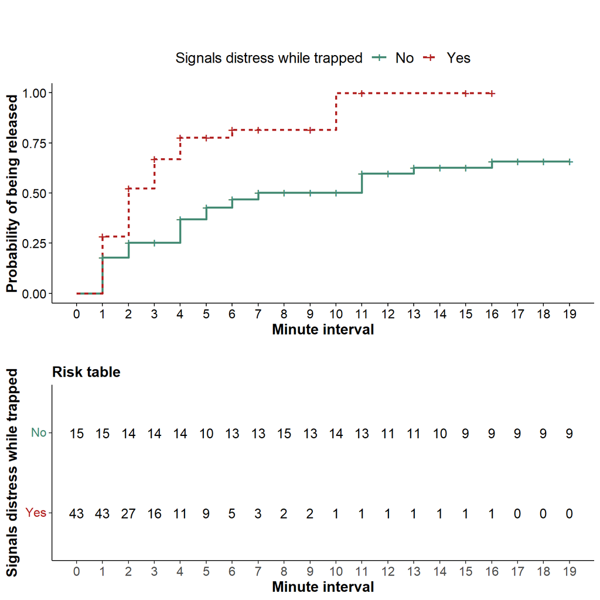

```r
plot
```

# How to cite R

“All analyses were performed using R Statistical Software (version 4.2.0; R Core Team 2022)”.

Reference: R Core Team (2022). R: A language and environment for statistical computing. R Foundation for Statistical Computing, Vienna, Austria. URL https://www.R-project.org/.

```r
citation()
```

```
  R Core Team (2022). R: A language and environment for statistical
  computing. R Foundation for Statistical Computing, Vienna, Austria.
  URL https://www.R-project.org/.

Ein BibTeX-Eintrag für LaTeX-Benutzer ist

  @Manual{,
    title = {R: A Language and Environment for Statistical Computing},
    author = {{R Core Team}},
    organization = {R Foundation for Statistical Computing},
    address = {Vienna, Austria},
    year = {2022},
    url = {https://www.R-project.org/},
  }

We have invested a lot of time and effort in creating R, please cite it
when using it for data analysis. See also 'citation("pkgname")' for
citing R packages.
```

```r
version$version.string
```

```
[1] "R version 4.2.0 (2022-04-22 ucrt)"
```

```r
citation("tidyverse")
```

```
Um Paket 'tidyverse' in Publikationen zu zitieren, nutzen Sie bitte:

  Wickham H, Averick M, Bryan J, Chang W, McGowan LD, François R,
  Grolemund G, Hayes A, Henry L, Hester J, Kuhn M, Pedersen TL, Miller
  E, Bache SM, Müller K, Ooms J, Robinson D, Seidel DP, Spinu V,
  Takahashi K, Vaughan D, Wilke C, Woo K, Yutani H (2019). "Welcome to
  the tidyverse." _Journal of Open Source Software_, *4*(43), 1686.
  doi:10.21105/joss.01686 <https://doi.org/10.21105/joss.01686>.

Ein BibTeX-Eintrag für LaTeX-Benutzer ist

  @Article{,
    title = {Welcome to the {tidyverse}},
    author = {Hadley Wickham and Mara Averick and Jennifer Bryan and Winston Chang and Lucy D'Agostino McGowan and Romain François and Garrett Grolemund and Alex Hayes and Lionel Henry and Jim Hester and Max Kuhn and Thomas Lin Pedersen and Evan Miller and Stephan Milton Bache and Kirill Müller and …
    year = {2019},
    journal = {Journal of Open Source Software},
    volume = {4},
    number = {43},
    pages = {1686},
    doi = {10.21105/joss.01686},
  }
```

```r
citation("fastDummies")
```

```
Um Paket 'fastDummies' in Publikationen zu zitieren, nutzen Sie bitte:

  Kaplan J (2020). _fastDummies: Fast Creation of Dummy (Binary)
  Columns and Rows from Categorical Variables_. R package version
  1.6.3, <https://CRAN.R-project.org/package=fastDummies>.

Ein BibTeX-Eintrag für LaTeX-Benutzer ist

  @Manual{,
    title = {fastDummies: Fast Creation of Dummy (Binary) Columns and Rows from
Categorical Variables},
    author = {Jacob Kaplan},
    year = {2020},
    note = {R package version 1.6.3},
    url = {https://CRAN.R-project.org/package=fastDummies},
  }
```

```r
citation("survival")
```

```
Um Paket 'survival' in Publikationen zu zitieren, nutzen Sie bitte:

  Therneau T (2022). _A Package for Survival Analysis in R_. R package
  version 3.3-1, <https://CRAN.R-project.org/package=survival>.

  Terry M. Therneau, Patricia M. Grambsch (2000). _Modeling Survival
  Data: Extending the Cox Model_. Springer, New York. ISBN
  0-387-98784-3.

To see these entries in BibTeX format, use 'print(<citation>,
bibtex=TRUE)', 'toBibtex(.)', or set
'options(citation.bibtex.max=999)'.
```

```r
citation("survminer")
```

```
Um Paket 'survminer' in Publikationen zu zitieren, nutzen Sie bitte:

  Kassambara A, Kosinski M, Biecek P (2021). _survminer: Drawing
  Survival Curves using 'ggplot2'_. R package version 0.4.9,
  <https://CRAN.R-project.org/package=survminer>.

Ein BibTeX-Eintrag für LaTeX-Benutzer ist

  @Manual{,
    title = {survminer: Drawing Survival Curves using 'ggplot2'},
    author = {Alboukadel Kassambara and Marcin Kosinski and Przemyslaw Biecek},
    year = {2021},
    note = {R package version 0.4.9},
    url = {https://CRAN.R-project.org/package=survminer},
  }
```

```r
citation("lmtest")
```

```
  Achim Zeileis, Torsten Hothorn (2002). Diagnostic Checking in
  Regression Relationships. R News 2(3), 7-10. URL
  https://CRAN.R-project.org/doc/Rnews/

Ein BibTeX-Eintrag für LaTeX-Benutzer ist

  @Article{,
    title = {Diagnostic Checking in Regression Relationships},
    author = {Achim Zeileis and Torsten Hothorn},
    journal = {R News},
    year = {2002},
    volume = {2},
    number = {3},
    pages = {7--10},
    url = {https://CRAN.R-project.org/doc/Rnews/},
  }
```